# Ford GoBike System Data exploration

## Preliminary Wrangling

> This dataset consists of information regarding 183412 trip from Ford GoBike on Feb, 2019. In this notebook, I'll do some exploratory data analysis for the data on hand.

```python
# import all packages and set plots to be embedded inline
import numpy as np
import pandas as pd
import matplotlib.pyplot as plt
import seaborn as sns

# hide warnings
import warnings
warnings.filterwarnings('ignore')

%matplotlib inline
```

```python
# load in the dataset into a pandas dataframe.
data = pd.read_csv('201902-fordgobike-tripdata.csv')
```

```python
# Print numnber of rows and columns in the dataset
data.shape
```

```
(183412, 16)
```

```python
# Print the first 5 rows of the dataset
data.head()
```

|  | duration_sec | start_time | end_time | start_station_id | start_station_name | start_station_latitude | start_station_longitude | end_station_id | end_station_name | end_station_latitude | end_station_longitude | bike_id | user_type | member_birth_year | member_gender | bike_share_for_all_trip |
| --- | --- | --- | --- | --- | --- | --- | --- | --- | --- | --- | --- | --- | --- | --- | --- | --- |
| 0 | 52185 | 2019-02-28 17:32:10.1450 | 2019-03-01 08:01:55.9750 | 21.0 | Montgomery St BART Station (Market St at 2nd St) | 37.789625 | -122.400811 | 13.0 | Commercial St at Montgomery St | 37.794231 | -122.402923 | 4902 | Customer | 1984.0 | Male | No |
| 1 | 42521 | 2019-02-28 18:53:21.7890 | 2019-03-01 06:42:03.0560 | 23.0 | The Embarcadero at Steuart St | 37.791464 | -122.391034 | 81.0 | Berry St at 4th St | 37.775880 | -122.393170 | 2535 | Customer | NaN | NaN | No |
| 2 | 61854 | 2019-02-28 12:13:13.2180 | 2019-03-01 05:24:08.1460 | 86.0 | Market St at Dolores St | 37.769305 | -122.426826 | 3.0 | Powell St BART Station (Market St at 4th St) | 37.786375 | -122.404904 | 5905 | Customer | 1972.0 | Male | No |
| 3 | 36490 | 2019-02-28 17:54:26.0100 | 2019-03-01 04:02:36.8420 | 375.0 | Grove St at Masonic Ave | 37.774836 | -122.446546 | 70.0 | Central Ave at Fell St | 37.773311 | -122.444293 | 6638 | Subscriber | 1989.0 | Other | No |
| 4 | 1585 | 2019-02-28 23:54:18.5490 | 2019-03-01 00:20:44.0740 | 7.0 | Frank H Ogawa Plaza | 37.804562 | -122.271738 | 222.0 | 10th Ave at E 15th St | 37.792714 | -122.248780 | 4898 | Subscriber | 1974.0 | Male | Yes |

```python
# Basic info about the dataset
data.info();
```

```
<class 'pandas.core.frame.DataFrame'>
RangeIndex: 183412 entries, 0 to 183411
Data columns (total 16 columns):
 #   Column                   Non-Null Count   Dtype
---  ------                   --------------   -----
 0   duration_sec             183412 non-null  int64
 1   start_time               183412 non-null  object
 2   end_time                 183412 non-null  object
 3   start_station_id         183215 non-null  float64
 4   start_station_name       183215 non-null  object
 5   start_station_latitude   183412 non-null  float64
 6   start_station_longitude  183412 non-null  float64
 7   end_station_id           183215 non-null  float64
 8   end_station_name         183215 non-null  object
 9   end_station_latitude     183412 non-null  float64
 10  end_station_longitude    183412 non-null  float64
 11  bike_id                  183412 non-null  int64
 12  user_type                183412 non-null  object
 13  member_birth_year        175147 non-null  float64
 14  member_gender            175147 non-null  object
 15  bike_share_for_all_trip  183412 non-null  object
dtypes: float64(7), int64(2), object(7)
memory usage: 22.4+ MB
```

```python
# Drop rows with null values
data.dropna(axis= 0, inplace= True)
```

```python
# Convert "start_time", and "end_time" variables into datetime type
for x in ["start_time", "end_time"]:
    data[x] = pd.to_datetime(data[x])
```

```python
# Convert "user_type", and "member_gender" features into nominal categorical datatype.
nom_var_dict = {'user_type': ['Customer', 'Subscriber'],
               'member_gender': ['Male', 'Other', 'Female']}

for var in nom_var_dict:
    nom_var = pd.api.types.CategoricalDtype(categories= nom_var_dict[var], ordered= False)
    data[var] = data[var].astype(nom_var)
```

```python
# Convert "member_birth_year" data type into intger.
data['member_birth_year'] = data['member_birth_year'].astype('int64')
```

```python
# Data types of variables included in the dataset after conversion
data.dtypes
```

```
duration_sec                        int64
start_time                 datetime64[ns]
end_time                   datetime64[ns]
start_station_id                  float64
start_station_name                 object
start_station_latitude            float64
start_station_longitude           float64
end_station_id                    float64
end_station_name                   object
end_station_latitude              float64
end_station_longitude             float64
bike_id                             int64
user_type                        category
member_birth_year                   int64
member_gender                    category
bike_share_for_all_trip            object
dtype: object
```

```python
# Summary statistics for numeric variables
data.select_dtypes(['int64','float64']).describe().T
```

|  | count | mean | std | min | 25% | 50% | 75% | max |
| --- | --- | --- | --- | --- | --- | --- | --- | --- |
| duration_sec | 174952.0 | 704.002744 | 1642.204905 | 61.000000 | 323.000000 | 510.000000 | 789.000000 | 84548.000000 |
| start_station_id | 174952.0 | 139.002126 | 111.648819 | 3.000000 | 47.000000 | 104.000000 | 239.000000 | 398.000000 |
| start_station_latitude | 174952.0 | 37.771220 | 0.100391 | 37.317298 | 37.770407 | 37.780760 | 37.797320 | 37.880222 |
| start_station_longitude | 174952.0 | -122.351760 | 0.117732 | -122.453704 | -122.411901 | -122.398279 | -122.283093 | -121.874119 |
| end_station_id | 174952.0 | 136.604486 | 111.335635 | 3.000000 | 44.000000 | 101.000000 | 238.000000 | 398.000000 |
| end_station_latitude | 174952.0 | 37.771414 | 0.100295 | 37.317298 | 37.770407 | 37.781010 | 37.797673 | 37.880222 |
| end_station_longitude | 174952.0 | -122.351335 | 0.117294 | -122.453704 | -122.411647 | -122.397437 | -122.286533 | -121.874119 |
| bike_id | 174952.0 | 4482.587555 | 1659.195937 | 11.000000 | 3799.000000 | 4960.000000 | 5505.000000 | 6645.000000 |
| member_birth_year | 174952.0 | 1984.803135 | 10.118731 | 1878.000000 | 1980.000000 | 1987.000000 | 1992.000000 | 2001.000000 |

```python
# Summary statistics for variables with object datatype.
data.select_dtypes(['object']).describe().T
```

|  | count | unique | top | freq |
| --- | --- | --- | --- | --- |
| start_station_name | 174952 | 329 | Market St at 10th St | 3649 |
| end_station_name | 174952 | 329 | San Francisco Caltrain Station 2 (Townsend St... | 4624 |
| bike_share_for_all_trip | 174952 | 2 | No | 157606 |

```python
# Summary statistics for datetime variables
data.select_dtypes(['datetime64[ns]']).describe().T
```

|  | count | unique | top | freq | first | last |
| --- | --- | --- | --- | --- | --- | --- |
| start_time | 174952 | 174941 | 2019-02-07 17:56:08.897 | 2 | 2019-02-01 00:00:20.636 | 2019-02-28 23:59:18.548 |
| end_time | 174952 | 174939 | 2019-02-28 17:40:37.328 | 2 | 2019-02-01 00:04:52.058 | 2019-03-01 08:01:55.975 |

```python
# Summary statistics for variables with category datatype.
data.select_dtypes(['category']).describe().T
```

|  | count | unique | top | freq |
| --- | --- | --- | --- | --- |
| user_type | 174952 | 2 | Subscriber | 158386 |
| member_gender | 174952 | 3 | Male | 130500 |

### What is the structure of your dataset?

> There are 183412 trips in this dataset with 16 features (duration_sec, start_time, end_time, start_station_id, start_station_name, start_station_latitude, start_station_longitude, end_station_id, end_station_name, end_station_latitude, end_station_longitude, bike_id, user_type, member_birth_year, member_gender, bike_share_for_all_trip).

### What is/are the main feature(s) of interest in your dataset?

> I'm interested in figuring out what features are best for predicting the trip duration. Aiming at that goal, I'll try to answer the following questions:

> ```
> 1. How long does the trip takes on average?,<br/>
> 2. Does it depend on user type?, <br/>
> 3. Does it depend on the time of the day? <br/>
> 4. How does average trip duration change over the week?, <br/>
> 5. Do Age and Sex of user affect the duration?
> ```

### What features in the dataset do you think will help support your investigation into your feature(s) of interest?

I think the following features will be the most important in our investigation:

- 'start_time': will help in determining the day of the week and time of the day for each trip,
- 'user_type': indicates whether the user is a memeber or a casual customer,
- 'member_gender': might have a strong relation with the trip duration, and
- 'member_birth_year': will be used to calculate the age of each user and may have a correlation with trip duration.

```python
# Creat a new feature to indicate the day of week.
data['day_of_week'] = data.start_time.dt.day_name()
```

```python
# Creat a new feature to indicate the time of day for each trip
data['time_of_day'] =  data.start_time.dt.hour
```

```python
# Creat a new feature to indicate the age of each member.
data['member_age'] = 2019 - data['member_birth_year']
```

```python
# Convert the units of trip duration from seconds to minutes
data['duration_min'] = data['duration_sec']/60
```

```python
# Drop columns that are not of interest to our analysis
data.drop(columns= ['start_station_id', 'start_station_latitude', 'start_station_longitude', 'end_station_id',
                    'end_station_latitude', 'end_station_longitude', 'bike_id', 'bike_share_for_all_trip'], inplace= True)
```

```python
# Saving modified data into separate csv file.
data.to_csv('modified_data.csv', index= False)
```

## Univariate Exploration

I'll start by looking at the distribution of the main variable of interest: duration_min.

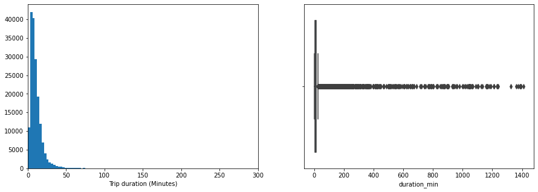

```python
# Distribution of the duration_min feature

fig, ax = plt.subplots(nrows= 1, ncols= 2, figsize= (15,5))
bin_size = 3
bins = np.arange(0, data.duration_min.max() + bin_size, bin_size)
ax[0].hist(data.duration_min, bins= bins)
ax[0].set_xlim([0, 300])
ax[0].set_xlabel('Trip duration (Minutes)')

sns.boxplot(data.duration_min, ax= ax[1]);
```

```python
data.duration_min.describe()
```

```
count    174952.000000
mean         11.733379
std          27.370082
min           1.016667
25%           5.383333
50%           8.500000
75%          13.150000
max        1409.133333
Name: duration_min, dtype: float64
```

The distribution is highly right_skewed with several extreme values. So, we will consider trip durations greater than the maximum whisker (Q3 + 1.5 IQR) as outliers and we will drop them out.

```python
# Calculate Q3
duration_q3 = data.duration_min.quantile(0.75)
# Calculate IQR
duration_IQR = data.duration_min.quantile(0.75) - data.duration_min.quantile(0.25)
# Get the index of outliers
outliers_indx = data.query('duration_min > @duration_q3 + @duration_IQR * 1.5').index
# Drop the outliers
data.drop(index= outliers_indx, inplace= True)
```

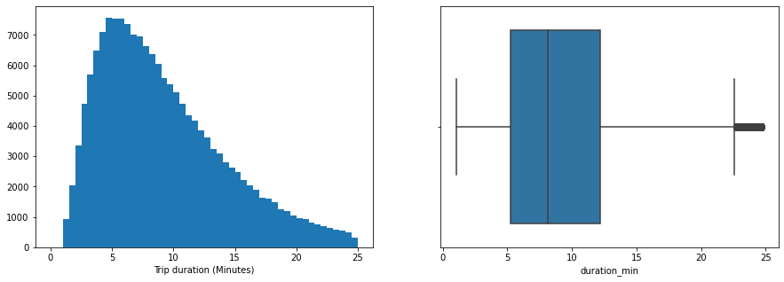

```python
# Distribution of the duration_sec feature after removing outliers

fig, ax = plt.subplots(nrows= 1, ncols= 2, figsize= (15,5))
bin_size = 0.5
bins = np.arange(0, data.duration_min.max() + bin_size, bin_size)
ax[0].hist(data.duration_min, bins= bins)
ax[0].set_xlabel('Trip duration (Minutes)')

sns.boxplot(data.duration_min, ax= ax[1]);
```

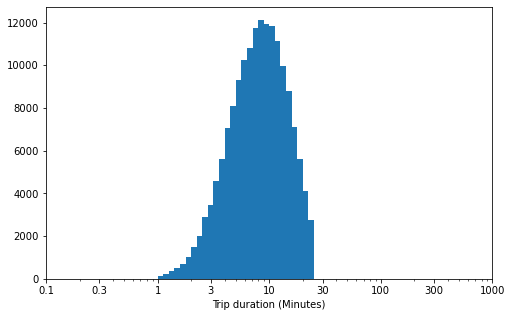

```python
# Distribution of the duration_sec feature after log transformation
bin_size = 0.05
bins = 10 ** np.arange(0, np.log10(data.duration_min.max()) + bin_size, bin_size)
plt.figure(figsize= (8,5))
plt.hist(data.duration_min, bins= bins)
plt.xscale('log')
plt.xticks([0.1, 0.3, 1, 3, 10, 30, 100, 300, 1000], ['0.1', '0.3', '1', '3', '10', '30', '100', '300', '1000'])
plt.xlabel('Trip duration (Minutes)');
```

The trip duration distribution is heavily right-skewed, with many trips on the short duration end, and few trips on the long duration trips. When plotted on a log-scale the trip duration distribution looks unimodal, with one large peak around 10 minutes.

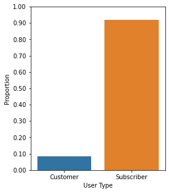

```python
# Creat a proportion plot for user_type

n_user = data['user_type'].value_counts().sum()
max_user_type = data['user_type'].value_counts()[0]
max_prop = max_user_type/n_user
tick_props = np.arange(0, max_prop + 0.1, 0.1)
tick_names = ['{:0.2f}'.format(v) for v in tick_props]

plt.figure(figsize= (4,5))
sns.countplot(data = data, x='user_type')
plt.yticks(tick_props * n_user, tick_names)
plt.xlabel('User Type')
plt.ylabel('Proportion');
```

The proportion plot for the user_type feature shows that about %90 of users are subscribers.

Now, I'll move to the second predictor of trip duration: day of week.

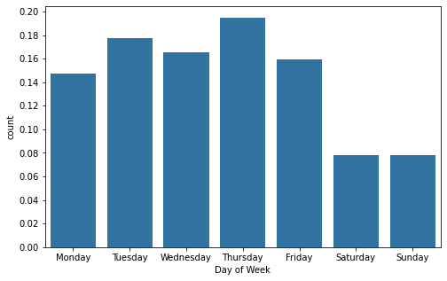

```python
# Creat a count plot for trips in each day of week
n_trips = data['day_of_week'].value_counts().sum()
max_day = data['day_of_week'].value_counts()[0]
max_prop = max_day/n_trips
tick_props = np.arange(0, max_prop + 0.02, 0.02)
tick_names = ['{:0.2f}'.format(v) for v in tick_props]

base_color = sns.color_palette()[0]
days_order = ['Monday', 'Tuesday', 'Wednesday', 'Thursday', 'Friday', 'Saturday', 'Sunday']
plt.figure(figsize= (8,5))
sns.countplot(data = data , x= 'day_of_week', order= days_order, color= base_color)
plt.yticks(tick_props * n_trips, tick_names)
plt.xlabel('Day of Week');
```

From the above proportions plot for number of trip on each day of the week, we can see that highest proportions of trips are on Thursday and the proportion of trips on the weekend is the lowest.

Next, I'll check the distribution of members' gender.

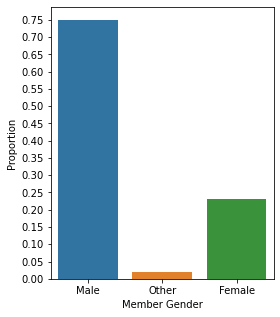

```python
# Creat a proportion plot for member_gender

n_user = data['member_gender'].value_counts().sum()
max_user_gender = data['member_gender'].value_counts()[0]
max_prop = max_user_gender/n_user
tick_props = np.arange(0, max_prop + 0.05, 0.05)
tick_names = ['{:0.2f}'.format(v) for v in tick_props]

plt.figure(figsize= (4,5))
sns.countplot(data = data, x='member_gender')
plt.yticks(tick_props * n_user, tick_names)
plt.xlabel('Member Gender')
plt.ylabel('Proportion');
```

The proportions plot for 'member_gender' shows that about 74% of members are males, and 24% are females.

Now, we check the distribution of members' age.

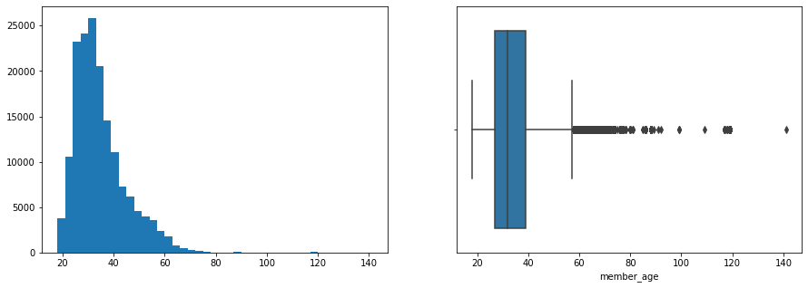

```python
# Histogram for member_age
fig, ax = plt.subplots(nrows= 1, ncols= 2, figsize= (15,5))

bin_size = 3
bins = np.arange(data.member_age.min(), data.member_age.max() + bin_size, bin_size)
ax[0].hist(x= data['member_age'],bins= bins)

sns.boxplot(data.member_age, ax= ax[1]);
```

The above histogram and box plot for 'member_age' indicate the distribution is right_skewed, with most users below 40 years, few users between 40 and 60, and very few users above 60.

Next, I'll check distribution of trips over the day.

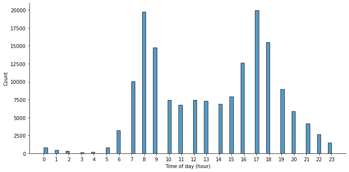

```python
# Histogram for number of trips over 'time_of_day'.
bin_size = 1
bins = np.arange(-0.5, data.time_of_day.max() + bin_size, bin_size)
plt.figure(figsize= (12,5))
sns.displot(data = data, x = 'time_of_day', color= base_color, aspect= 2)
# plt.hist(data.time_of_day, color= base_color, bins= bins, )
plt.xlabel('Time of day (hour)')
xticks = np.arange(0, 24,1)
plt.xticks(xticks, ['{}'.format(v) for v in xticks])
sunrise_avg = 7 #Source: (https://www.sunrise-and-sunset.com/en/sun/united-states/california__mo/2019/february)
sunset_avg = 17.8 #Source: (https://www.sunrise-and-sunset.com/en/sun/united-states/california__mo/2019/february)
# # plot a vertical time to indicate the sunrise.
# plt.axvline(x = sunrise_avg, ymin=0 , ymax = 20000, color = 'red', linestyle = '--', label = 'Sunrise')
# # plot a vertical time to indicate the sunset.
# plt.axvline(x = sunset_avg, ymin=0 , ymax = 20000, color = 'red', linestyle = '--', label = 'Sunset');
```

The above histogram for number of trips over the day shows that the distribution is bimodal, with one big peak around 8 am, and one big peak around 5 pm.

I'll now look at the other features in the data to see if any of them hold interesting properties. Let's start by "start_station_name" and "end_station name".

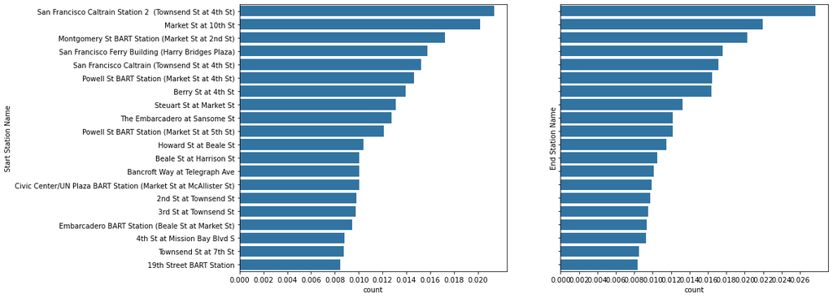

```python
# Creat a proportions plot for start and end stations.

fig, ax = plt.subplots(nrows= 1, ncols= 2, figsize= (15, 7), sharey= True)
base_color = sns.color_palette()[0]

# Proportions plot for 'start_station_name'
start_station_count = data.start_station_name.value_counts()
n_start_station = start_station_count.sum()
max_start_station = start_station_count[0]
max_prop_start = max_start_station/n_start_station
xticks_props_start = np.arange(0, max_prop_start, 0.002)
xticks_label_start = ['{:0.3f}'.format(v) for v in xticks_props_start]
sns.countplot(data = data , y= 'start_station_name', order= start_station_count.index[:20], color= base_color, ax= ax[0])
ax[0].set_xticks(xticks_props_start * n_start_station)
ax[0].set_xticklabels(xticks_label_start)
ax[0].set_ylabel('Start Station Name')

# Proportions plot for 'end_station_name'
end_station_count = data.end_station_name.value_counts()
n_end_station = end_station_count.sum()
max_end_station = end_station_count[0]
max_prop_end = max_end_station/n_end_station
xticks_props_end = np.arange(0, max_prop_end, 0.002)
xticks_label_end = ['{:0.3f}'.format(v) for v in xticks_props_end]
sns.countplot(data = data , y= 'end_station_name', order= end_station_count.index[:20], color= base_color, ax= ax[1])
ax[1].set_xticks(xticks_props_end * n_end_station)
ax[1].set_xticklabels(xticks_label_end)
ax[1].set_ylabel('End Station Name');
```

From the above bar plots, we can see that the flow of trips is almost balanced, stations used most frequently as starting point are also the most frequently used stations as end point.

### Discuss the distribution(s) of your variable(s) of interest. Were there any unusual points? Did you need to perform any transformations?

The trip duration took a large range of values. It was highly right-skewed so I looked at the data using log transformation. After transformation, the data looked unimodal, with one large peak around 10.

Trips took place mainly at two time over the day, first at 8 am, and second at 5 pm.

### Of the features you investigated, were there any unusual distributions? Did you perform any operations on the data to tidy, adjust, or change the form of the data? If so, why did you do this?

We needed to convert the datatype of some features as follows:

1. 'start_time' and 'end_time' features are converted from 'object' into 'datatime' to facilitate extracting time related info from this feature,
2. 'user_type', and 'member_gender' features are converted from 'object' into 'category' to facilitate calculating summary statistics and creating visualizations, and
3. 'member_birth_year' feature is converted from 'float' into 'int' to facilitate ploting using appropriate plot type.

## Bivariate Exploration

> In this section, I'll investigate relationships between pairs of features in the date on hand.

To start off with, I want to look at the pairwise relationships between the categorical features in the data and trip_duration.

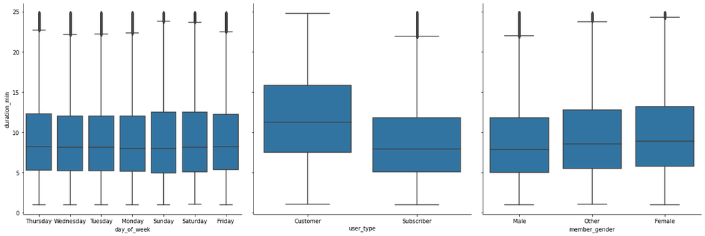

```python
catg_vars = ['day_of_week', 'user_type', 'member_gender']

# Creat a box plot for each categorical variable vs. duration_min
def boxgrid(x, y, **kwargs):
    default_color = sns.color_palette()[0]
    sns.boxplot(x, y, color = default_color)

g = sns.PairGrid(data = data, y_vars = ['duration_min'], x_vars = catg_vars, size= 6)
g.map(boxgrid)
plt.show();
```

The above box plots shows that:

1. All most there's no relationship between the day_of_week and duration_min.
2. Most of customers tend to have longer trip durations than subscribers.
3. All most there's no relationship between member_gender and duration_min.

Next, I'll check the pairwise relationships between numerical features.

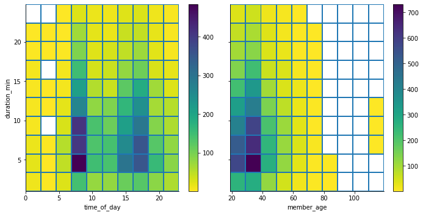

```python
num_vars = ['time_of_day', 'member_age']

# Creat a 2D histogram for numerical vairables vs. duration_min
def hist2d(x, y, **kwargs):
    default_color = sns.color_palette()[0]
    plt.hist2d(x, y, color = default_color, cmin= 1, cmap='viridis_r')
    plt.colorbar()

g = sns.PairGrid(data = data.sample(frac= 0.05), y_vars = ['duration_min'], x_vars = num_vars, size= 5 )
g.map(hist2d)
plt.show();
```

The above 2D histograms show that:

1. Most of trips are around 8 am and 5 pm with duration between 5 and 10 minutes.
2. The vast majority of members are below 40 years and their trip duration ranges mostly between 4 and 11 minutes.

Let's check the correlation between the numeric features.

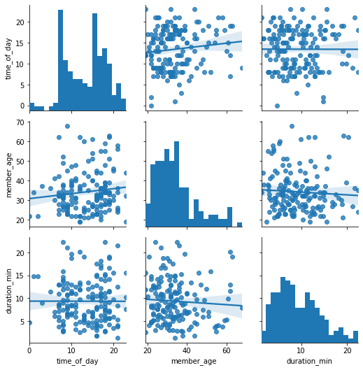

```python
# plot matrix for a sample of 0.01% of trips so that plots are clearer and they render faster
g = sns.PairGrid(data = data.sample(frac= 0.001), vars = ['time_of_day', 'member_age', 'duration_min'], size= 2.5)
g = g.map_diag(plt.hist, bins = 20)
g.map_offdiag(sns.regplot);
```

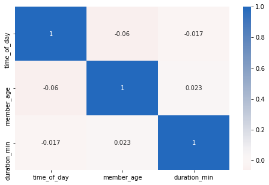

```python
# correlation plot between numeric variables
plt.figure(figsize = [8, 5])
sns.heatmap(data= data[['time_of_day', 'member_age', 'duration_min']].corr(), cmap = 'vlag_r', center = 0, annot= True)
```

The above scatter plots and correlation plot show that there's almost no direct relationship between those features.

Let's have a closer look at the relationship between member age and trip duration between dividing age into chuncks based on quartiles ('below 27', 'between 27 and 32', 'between 32 and 39', and 'Above 39')

```python
data.member_age.describe()
```

```
count    165624.000000
mean         34.165266
std          10.041214
min          18.000000
25%          27.000000
50%          32.000000
75%          39.000000
max         141.000000
Name: member_age, dtype: float64
```

```python
# Function to divide the age into chunks
def age_bin(x):
    if x < 27:
        return 'below 27'
    elif x < 32:
        return 'between 27 and 32'
    elif x < 39:
        return 'between 32 and 39'
    else:
        return 'Above 39'
```

```python
# Create a new feature to store the age chunk to which each member belongs.
data['age_chunk'] = data.member_age.apply(lambda x: age_bin(x))
```

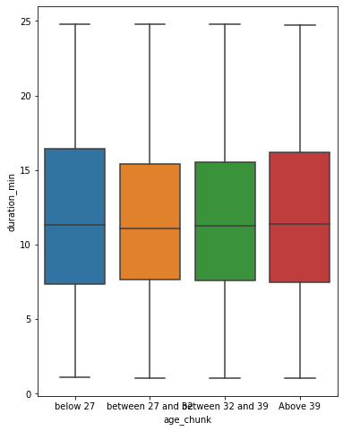

```python
# Creat a box plot for age_bin vs. duration_min
age_order = ['below 27', 'between 27 and 32', 'between 32 and 39', 'Above 39']
plt.figure(figsize= [6,8])
sns.boxplot(data= data.query('user_type == "Customer"'), x= 'age_chunk', y= 'duration_min', order= age_order)
```

It seems dividing member age into chunks didn't reveal more information about the relationship between member_age and trip duration.

Next, let's look at relationships between the three categorical features.

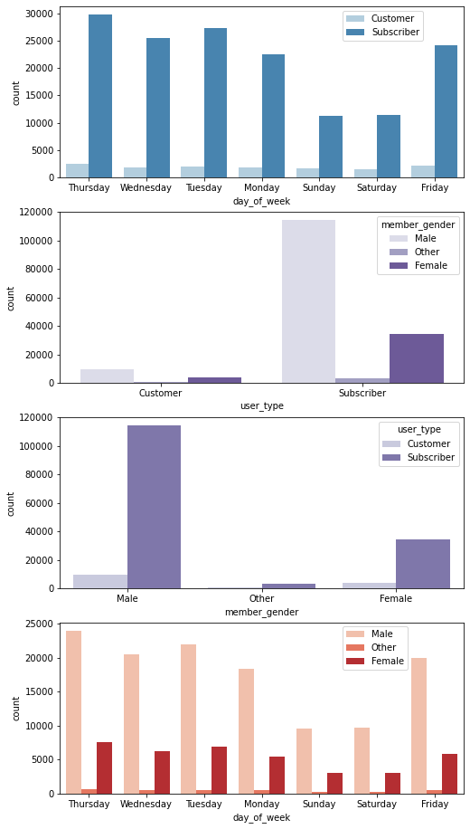

```python
# Creat subplots for the countplot for each pair of the categorical features.
plt.figure(figsize = [8, 16])

# subplot 1: day_of_week vs user_type
ax = plt.subplot(4, 1, 1)
sns.countplot(data = data, x = 'day_of_week', hue = 'user_type', palette = 'Blues')
ax.legend(loc= [0.7,0.8]) # re-arrange legend to reduce overlapping

# subplot 2: member_gender vs. user_type
ax = plt.subplot(4, 1, 2)
sns.countplot(data = data, x = 'user_type', hue ='member_gender', palette = 'Purples')

# subplot 2: member_gender vs. user_type
ax = plt.subplot(4, 1, 3)
sns.countplot(data = data, x = 'member_gender', hue ='user_type', palette = 'Purples')

# subplot 3: day_of_week vs. member_gender
ax = plt.subplot(4, 1, 4)
sns.countplot(data = data, x = 'day_of_week', hue = 'member_gender', palette = 'Reds')
ax.legend(loc = [0.7, 0.725]) # re-arrange legend to remove overlapping

plt.show()
```

The count plot for member_gender vs. user_type shows that the proportion of males who subscribe to the service is larger than that of females.

Let's check the relationship between memeber_gender and memeber_age.

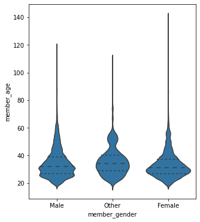

```python
# Create a violinplot between member_gender and memeber_age
plt.figure(figsize= (5,6))
sns.violinplot(data= data, x= 'member_gender', y= 'member_age', color= base_color, inner= 'quartile');
```

Next, I'll check the relationship between user_type and memeber_age.

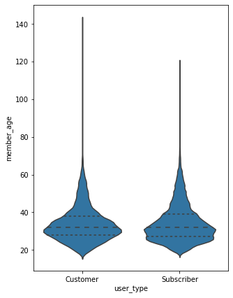

```python
# Create a violinplot between user_type and memeber_age
plt.figure(figsize= (5,7))
sns.violinplot(data= data, x= 'user_type', y= 'member_age', color= base_color, inner= 'quartile');
```

Finally, I'll check if males and females have different preferred riding times.

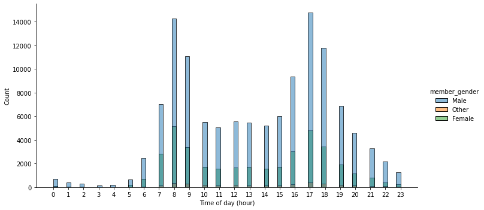

```python
# Histogram for number of trips over 'time_of_day' for gender.
bin_size = 1
bins = np.arange(-0.5, data.time_of_day.max() + bin_size, bin_size)
plt.figure(figsize= (12,5))
sns.displot(data = data, x = 'time_of_day', color= base_color, aspect= 2, hue= 'member_gender')
plt.xlabel('Time of day (hour)')
xticks = np.arange(0, 24,1)
plt.xticks(xticks, ['{}'.format(v) for v in xticks]);
```

The above histogram shows that males and females have similar riding times with two peaks over the day, the first at 8 am, and the second is at 5 pm.

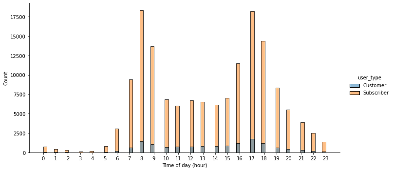

```python
# Histogram for number of trips over 'time_of_day' for user type.
bin_size = 1
bins = np.arange(-0.5, data.time_of_day.max() + bin_size, bin_size)
plt.figure(figsize= (12,5))
sns.displot(data = data, x = 'time_of_day', color= base_color, aspect= 2, hue= 'user_type')
plt.xlabel('Time of day (hour)')
xticks = np.arange(0, 24,1)
plt.xticks(xticks, ['{}'.format(v) for v in xticks]);
```

The histogram for time of day vs. user type shows that the two peak pattern applies regardless of the user type.

### Talk about some of the relationships you observed in this part of the investigation. How did the feature(s) of interest vary with other features in the dataset?

> Surprisingly, the average trip duration didn't change over the week while I expected it to be different for weekends.

> Also, it was surprising to me to know that trip duration doesn't depend on member age.

> As expected, customers tend to have longer trips than subscribers because they may ride for long trips compared to routine daily commuting for subscribers.

### Did you observe any interesting relationships between the other features (not the main feature(s) of interest)?

> We observed that most of subscribers are males who may use bikes for their daily commuting. On the other hand, the proportion of subscribers from females is smaller compared to males.

> Different of what I have expected, riding times over the day don't depend on the gender. Both males and females seem to have similar riding time pattern.

## Multivariate Exploration

> In this section, I'll preform some multivariate explorations to further explore the data on hand.

To start by, I'll check the relationship between the gender, trip duration, and user type.

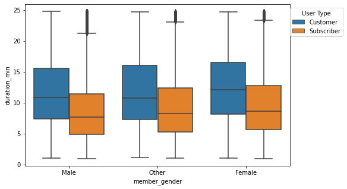

```python
# Create a boxplot between member_gender, duration_min and user_type
plt.figure(figsize= (8,5 ))
sns.boxplot(data= data, x = 'member_gender', y= 'duration_min', hue= 'user_type')
plt.legend(loc = [1,0.8], title= 'User Type');
```

The above box plot shows that the trip duration for customers is consistently longer than that of subscribers regardless of the gender.

Next, I'll check if the relationship between the trip duration, and day of week depndes on the user type.

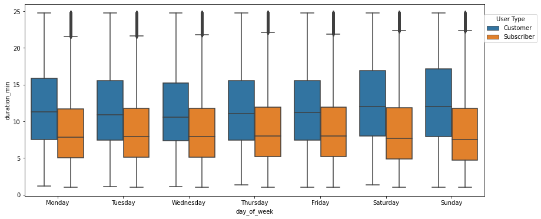

```python
# Create a boxplot between day_of_week, duration_min, and user_type.
plt.figure(figsize= (14,6))
sns.boxplot(data= data, x = 'day_of_week', y= 'duration_min', hue= 'user_type',
            order = ['Monday', 'Tuesday', 'Wednesday', 'Thursday', 'Friday', 'Saturday', 'Sunday'])
plt.legend(loc = [1,0.8], title= 'User Type');
```

The above box plot shows that the trip duration for customers is consistently longer than that of subscribers over the week, and specially on weekends. This may be due to the fact that customers are irregular users who ride occationally for entertainment purpose.

Now, I'll check if there are some days over the week when males tend to ride longer than females.

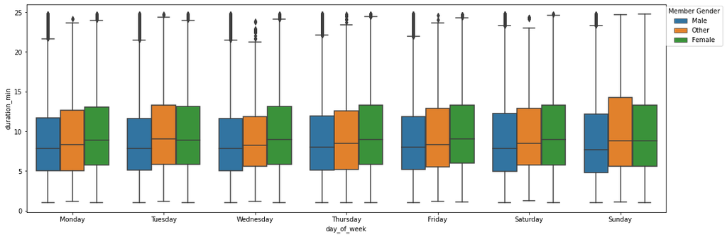

```python
# Create a boxplot between day_of_week, duration_min and member_gender.
plt.figure(figsize= (18,6))
sns.boxplot(data= data, x = 'day_of_week', y= 'duration_min', hue= 'member_gender',
            order = ['Monday', 'Tuesday', 'Wednesday', 'Thursday', 'Friday', 'Saturday', 'Sunday'])
plt.legend(loc = [1,0.8], title= 'Member Gender');
```

The above box plot shows that the median trip duration for females is always larger than that of males over the week.

Next, let's check if the relationship between member age, and trip duration depends on the member gender.

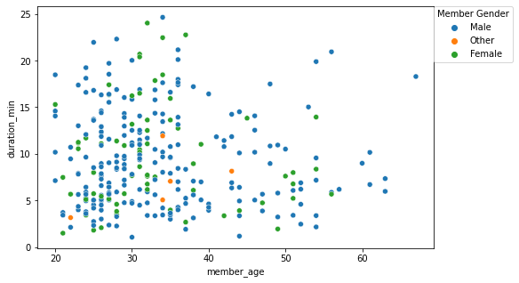

```python
# Creat a scatter plot between member_age, duration_min and member_gender
plt.figure(figsize=(8,5))
sns.scatterplot(data= data.sample(300), x= 'member_age', y='duration_min', hue = 'member_gender')
plt.legend(loc = [1,0.77], title= 'Member Gender');
```

As we see in the bivariate exploration section, the correlation between the member age and trip duration is very small.The scatter plot shows that there's no unique pattern for the relationship between member_age, and trip duration depending on the gender.

Finally, I'll check if the relationship between member age, and trip duration depends on the user type.

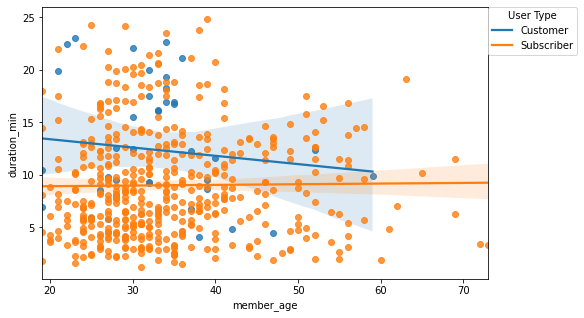

```python
# Create a scatter plot between member_age, duration_min and user_type.
plt.figure(figsize=(8,5))
sns.regplot(data= data.sample(500).query('user_type == "Customer"'), x= 'member_age', y='duration_min')
sns.regplot(data= data.sample(500).query('user_type == "Subscriber"'), x= 'member_age', y='duration_min')
plt.legend(loc = [1,0.825], title= 'User Type', labels= ['Customer', 'Subscriber']);
```

The scatter plot between member age vs. trip duration vs. user type shows that:

1. Most of Subscribers are below 40 years, and ride for less than 15 min. On the other hand,
2. there's a clearer negative relationship between member age, and trip duration for customers .

### Talk about some of the relationships you observed in this part of the investigation. Were there features that strengthened each other in terms of looking at your feature(s) of interest?

> I observed that the trip duration for customers is longer than that for subscribers regardless of day of week.

> Also, I've noticed that trip durations for females are slightly longer than that of males.

### Were there any interesting or surprising interactions between features?

> I've noticed an interaction between member age, trip duration and user type. While it seems there's no relation ship between member age and trip duration for subscribers, a negative relationship appears between the two for customers.